# Praca domowa 1

Mateusz Dolinski

05.03.2019

# Wczytanie danych

Na poczatek sciagamy zip z danymi do tymczasowego pliku:

```r
url <- 'https://stacks.stanford.edu/file/druid:hg921sg6829/HCMST_2017_public_data_v1.1_stata.zip'
temp <- tempfile()
download.file(url,
              temp)
```

Nastepnie wczytujemy dane przy pomocy pakietu **haven**:

```r
DATA <- read_stata(unzip(temp))
rm(temp)
```

# Eksploracja

Wyciągnijmy zmienną celu oraz wybrane zmienne objaśniające. Są to:

- Q9: How old is [Partner name]?
- Q19: Are you currently living with [Partner name]? (1 - yes, 2 - no)
- Q26: Did you and [Partner name] attend he same college or university? (1 - yes, 2 - no)
- ppage: Age

Zmienna celu jest:

- S1: Are you married? (1 - yes, 2 - no)

Usuniete zostana rekordy z brakami danych lub odmowa odpowiedzi na ktores z uwzglednionych pytan. Po czyszczeniu pozostalo 1595 obserwacji.

```r
columns <- c('S1', 'Q9', 'Q19', 'Q26', 'ppage')
DATA.TRAIN <- DATA %>%
              select(columns) %>%
              filter(Q26 > 0) %>%
              filter(complete.cases(.)) %>%
              mutate(S1    = as.factor(S1 - 1),
                     Q19   = as.factor(Q19 - 1),
                     Q26   = as.factor(Q26 - 1),
                     Q9    = as.numeric(Q9),
                     ppage = as.numeric(ppage))
```

# Trening i wizualizacja

Trenujmy las losowy:

```r
set.seed(1)
rf_model <- randomForest(S1 ~ .,
                         data = DATA.TRAIN,
                         ntree=20,
                         maxmodes=5)
y_pred <- predict(rf_model, DATA.TRAIN[, -1])
conf.matrix <- table(DATA.TRAIN$S1, y_pred)
acc <- sum(diag(conf.matrix)) / sum(conf.matrix)
print(sprintf('Accuracy equals to %2.4f', acc))
```

```
[1] "Accuracy equals to 0.8934"
```

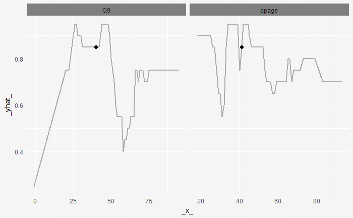

```r
explainer_rf <- explain(rf_model,
                        data = DATA.TRAIN,
                        y = DATA.TRAIN$S1)
new_person <- data.frame(Q9 = 40.,
                         Q19 = factor(1, levels = c(0,1)),
                         Q26 = factor(0, levels = c(0, 1)),
                         ppage = 41.)
cp_rf <- ceteris_paribus(explainer_rf,
                         new_person,
                         variables = c("Q9", "ppage"))
plot(cp_rf,
     alhpa = 0,
     color='black')
```

oraz wykresy dla obu zmiennych jednoczesnie:

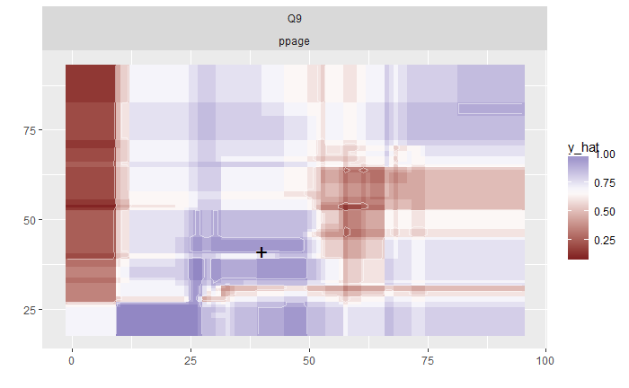

```r
wi_rf_2d <- what_if_2d(explainer_rf,
                       observation = new_person,
                       selected_variables =  c('Q9', 'ppage'))
plot(wi_rf_2d,
     split_ncol = 2)
```

# Wnioski

Kolejna ciekawostka jest ‘dziura’ w przypadku partnerow w wieku 50-60 lat oraz ‘wysepka’ dla partnerow powyzej 75 lat. Model sugeruje, ze w pierwszym przypadku osoby te sa zamezne a w drugim nie. Moze to wynikac z demografii lub obciazenia proby.